# Access and value of obesity drugs in Medicaid: coverage effect, eligible population, prescribers and budget impact

Study report, public aggregate data (CMS, NHANES, MEPS, KFF), 2018 to early 2026

Author

Erick Kiprotich Yegon · Epidemiologist and data scientist

Published

October 5, 2026

**Disclaimer.** Public aggregate data; no company affiliation or endorsement. These are not patient-level claims. Medicaid cost figures are gross of rebates unless stated. Results for prescribers and payments are associations, and scenarios are not forecasts or effects of any company’s promotion.

# The answer

When Medicaid programs began covering Wegovy and Zepbound for obesity, prescriptions rose by an estimated 12.2 per 1,000 enrollees per quarter on average (95% CI 8.4 to 16.0), comparing 10 covering states with 34 never-covering jurisdictions. The effect grew from 1.3 in the first quarter to 11.7 after four quarters and 17.2 after eight, partly because the national market grew at the same time. About 128.8 million U.S. adults meet the FDA label criteria (lower bound; 95% CI 117.2 to 140.3 million), including 17.8 million with Medicaid. For a state program of 1 million enrollees, the five-year net budget impact in the central case is **$161.3 million**, or **$2.69 per enrollee per month**, with a scenario range of $55.6 to $369.4 million that is driven mainly by two things the data cannot give: the rebate and the later years. At the announced $245 per monthly prescription, the central case would be $68.3 million ($1.14 per enrollee per month).

Every number in this report is read from `analysis/outputs/key_numbers.csv`, which links each one to the output file and row it came from.

# A. Data and coding layer

A tested warehouse stands behind every number.

Public sources were loaded into PostgreSQL and transformed with dbt: Medicaid State Drug Utilization Data (SDUD) and enrollment, Medicare Part D Prescribers, NADAC drug prices, Open Payments, NPPES and NUCC taxonomy, NHANES, MEPS, ICD-10-CM value sets, FDA labels and the NDC directory, and state policy documents. A product map assigns each NDC to a drug, brand and label group using the FDA label indications text. The build has 54 dbt models (32 staging, 10 intermediate, 12 marts), 10 seeds and 126 tests, counted from the dbt manifest (`analysis/outputs/build_counts.csv`).

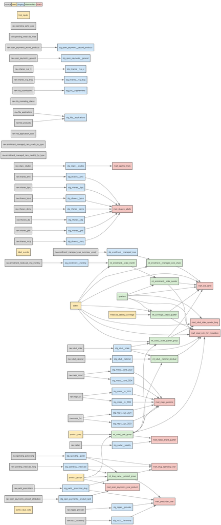

dbt lineage: raw sources through staging and intermediate models to the marts used in the analyses

Pre-specified analysis plans were committed before any results of each module: Module C `d46bd57` (2026-10-04 06:16 -0400; amendment `f74da18`, 2026-10-04 07:09 -0400, before any model run), Module B `7909c7a` (2026-10-04 09:11 -0400), Module D `6d4234f` (2026-10-04 09:28 -0400) and Module E `993e8c8` (2026-10-04 09:39 -0400). Commit hashes changed when history was rewritten to remove personal metadata and third-party copies; dates and order are unchanged. Departures from the plans are logged in [`deviations.md`](https://github.com/erickyegon/incretin-access-value/blob/main/analysis/outputs/deviations.md) (items 1 to 17).

### From NDC to label group

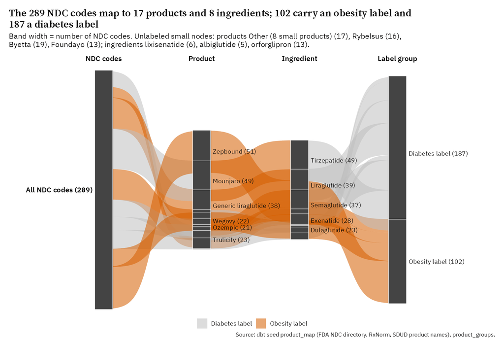

Counts are NDC codes, not prescriptions.

The product map holds 289 NDC codes. They resolve to 17 products (brands and generics) and 8 ingredients; 102 codes carry an obesity label and 187 a diabetes label. Counts are NDC codes, not prescriptions; the full count table is `analysis/outputs/tables/moduleA_ndc_product_ingredient_label_counts.csv`.

## Market context: spending, timeline and pipeline

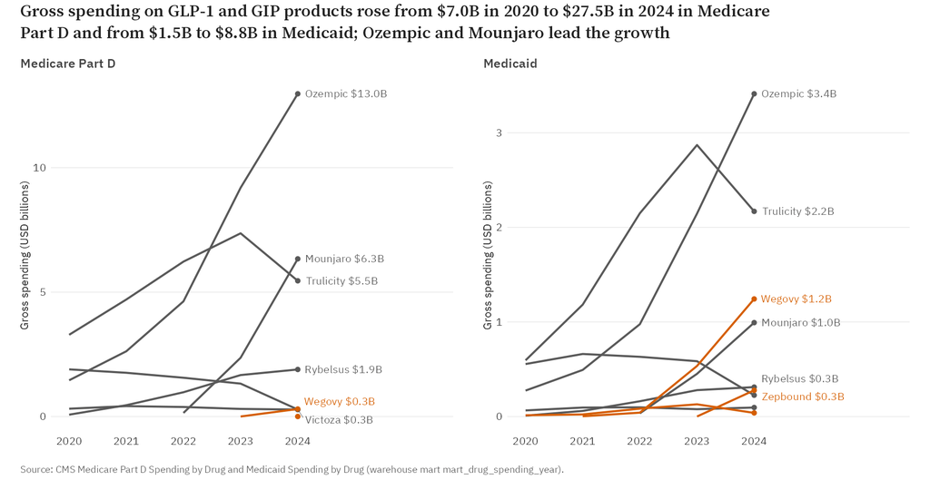

Spending is gross of rebates. Orange: brands labeled for obesity (Wegovy, Zepbound, Saxenda); gray: diabetes brands. Part D brands also include diabetes and other covered uses; Victoza packs are combined. CMS outlier flags are kept.

Gross spending on GLP-1 and GIP products rose from $7.0 billion in 2020 to $27.5 billion in 2024 in Medicare Part D and from $1.5 billion to $8.8 billion in Medicaid. These are CMS spending figures **before manufacturer rebates**, so they overstate what programs pay. Ozempic ($13.0 billion) and Mounjaro ($6.3 billion) lead in Part D in 2024, mostly diabetes use; in Medicaid, Wegovy ($1.2 billion) is the largest obesity-labeled brand.

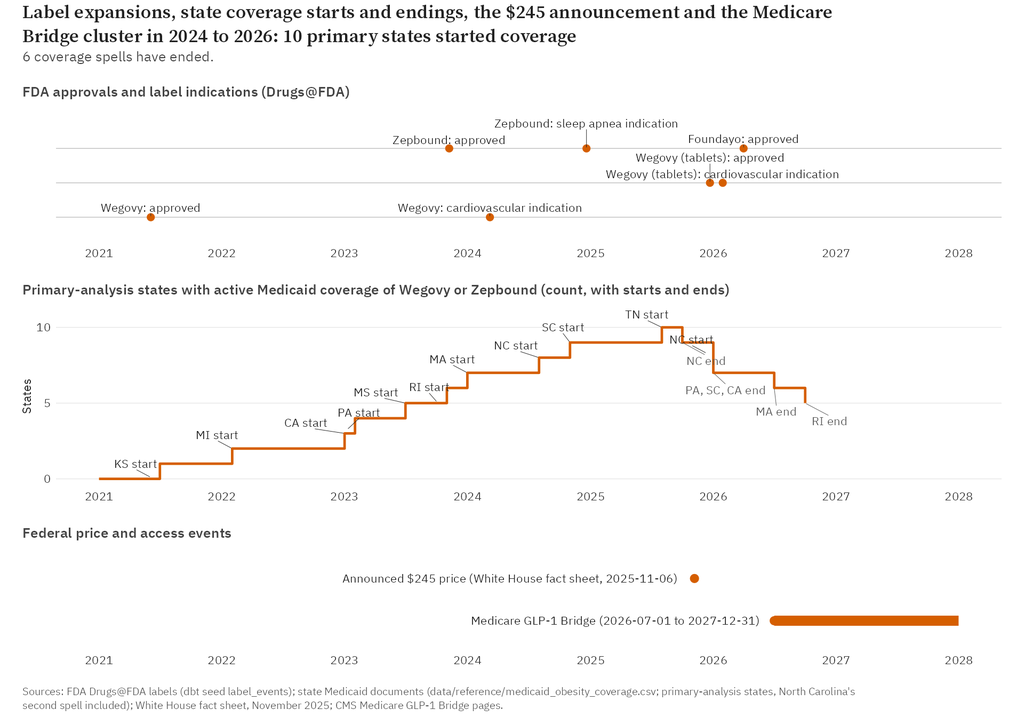

Coverage counts use the first day of the start month and the day after the end date; Saxenda (approved 2014) is outside the window.

The pipeline of registered studies (ClinicalTrials.gov, in-scope ingredients only: semaglutide, tirzepatide, liraglutide, dulaglutide, exenatide and orforglipron) has 634 studies listing obesity, of which 297 are ongoing and 59 are ongoing Phase 3. Oral programs account for 46 obesity studies (9 ongoing Phase 3; “oral” is matched on orforglipron or oral or tablet text and is approximate), and orforglipron alone has 23 obesity studies, 14 of them Phase 3. Programs of other ingredients are not counted.

| Registered phase | Obesity studies | Ongoing |
| --- | --- | --- |
| Phase 1 (including early Phase 1) | 80 | 28 |
| Phase 2 (including Phase 1/2) | 105 | 53 |
| Phase 3 (including Phase 2/3) | 147 | 59 |
| Phase 4 | 133 | 58 |
| Not applicable / not stated | 169 | 99 |

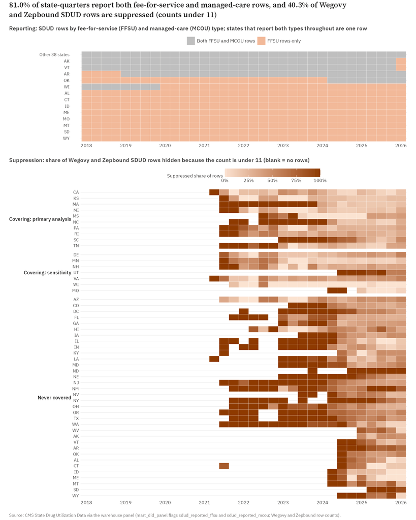

States are ordered by the number of quarters with both utilization types. Counts under 11 are suppressed by CMS; no suppressed value is shown.

The reporting heatmap shows that 81.0% of state-quarters have both fee-for-service and managed-care rows and 19.0% have fee-for-service rows only; 40.3% of Wegovy and Zepbound rows are suppressed (counts under 11), which is why Module C imputes suppressed cells.

# B. Funnel and forecast

About half of U.S. adults meet the label criteria, and use is rising.

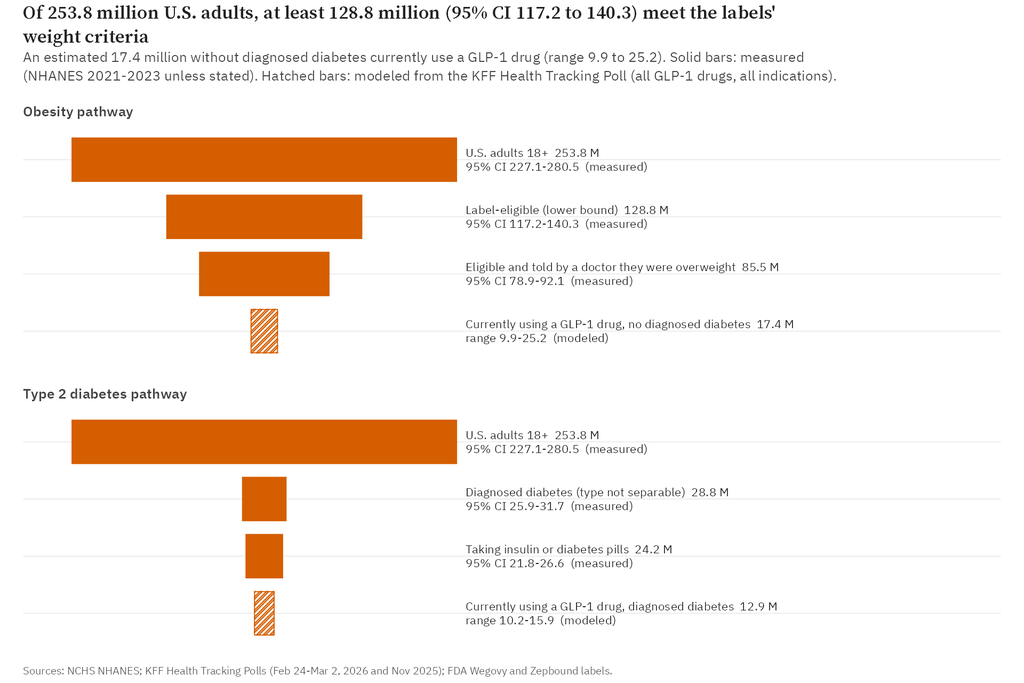

The eligible count is a lower bound: sleep apnea and other label conditions are not measurable in NHANES. Bar widths are proportional to people. Told-overweight step uses the 2017-2020 file (not asked in 2021-2023).

Of 253.8 million adults, 128.8 million (55.0% of adults with the measure) are label-eligible by BMI of 30 or more, or BMI 27 to 29.9 with a measurable weight-related condition. This is a lower bound, because some qualifying conditions are not measured in NHANES. Among adults with Medicaid (34.3 million), 17.8 million (52.0%) are eligible. The measurable part of the Medicare GLP-1 Bridge criteria covers 10.8 million adults aged 65 and over. KFF’s poll puts current GLP-1 use at 30.4 million adults (95% CI 23.5 to 37.5), of whom about 17.4 million do not have diagnosed diabetes (a weight-management proxy, modeled).

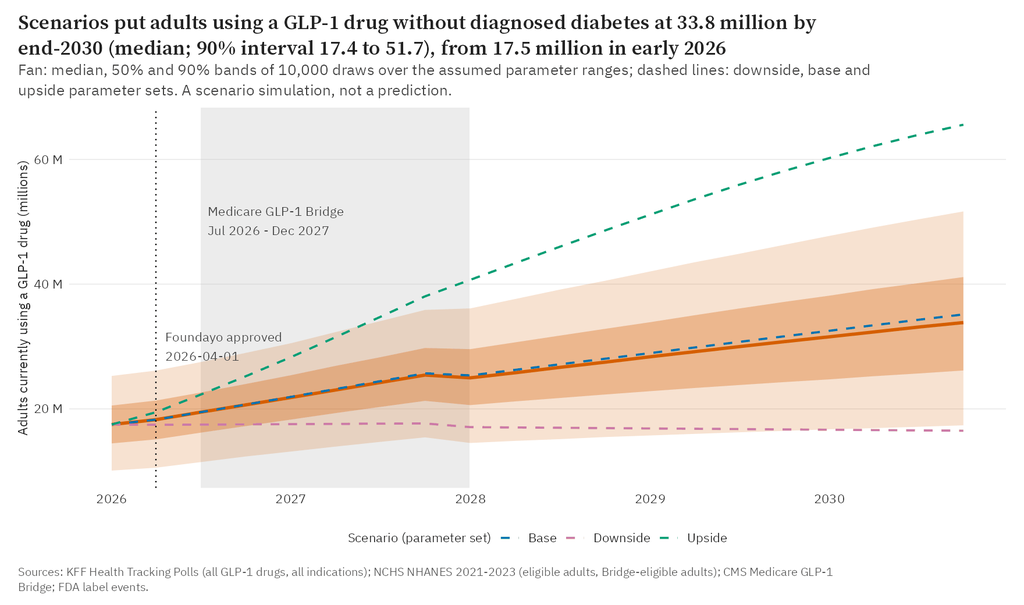

The group includes use for heart disease and is a proxy for weight-management use. Growth, ceiling and access-event sizes are assumptions listed in moduleB_assumptions.csv.

### BMI class and diabetes by age and sex

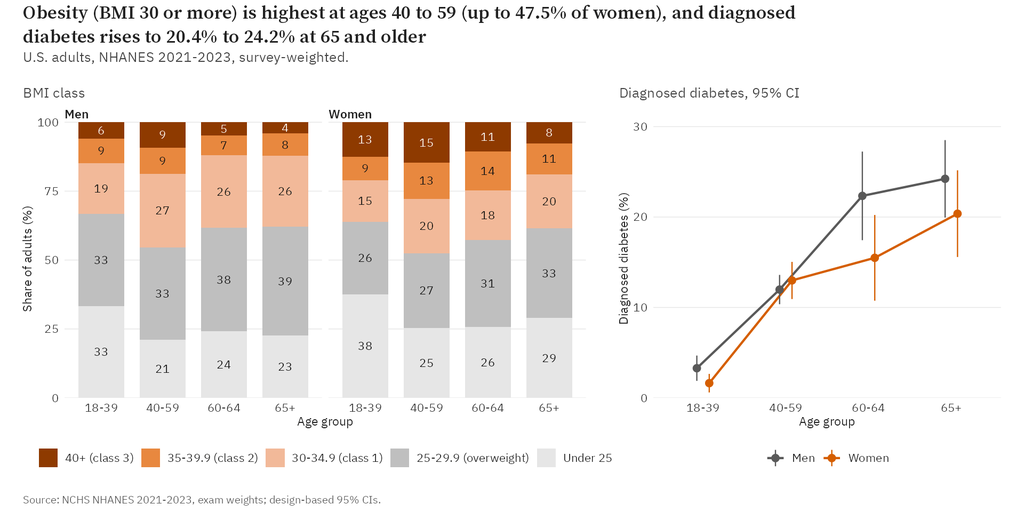

Prevalence among adults with the measure available. Cell labels are percent of adults.

| Age | Men BMI 30+, % | Men diagnosed diabetes, % (95% CI) | Women BMI 30+, % | Women diagnosed diabetes, % (95% CI) |
| --- | --- | --- | --- | --- |
| 18-39 | 33.3 | 3.3 (1.9 to 4.7) | 36.1 | 1.6 (0.6 to 2.6) |
| 40-59 | 45.4 | 12.0 (10.4 to 13.6) | 47.5 | 13.0 (10.9 to 15.0) |
| 60-64 | 38.3 | 22.3 (17.4 to 27.2) | 42.7 | 15.5 (10.8 to 20.2) |
| 65+ | 37.9 | 24.2 (19.9 to 28.5) | 38.5 | 20.4 (15.6 to 25.2) |

Survey-weighted prevalence among adults with the measure available; BMI 30+ is the sum of classes 1 to 3. Full table with every BMI class: moduleB_prevalence_age_sex.csv.

Obesity (BMI 30 or more) peaks at ages 40 to 59, reaching 47.5% in the highest group (women aged 40 to 59). Diagnosed diabetes rises with age to 24.2% of men and 20.4% of women at 65 and older.

# C. Coverage study

Coverage was associated with more prescriptions, quickly at first and more over time.

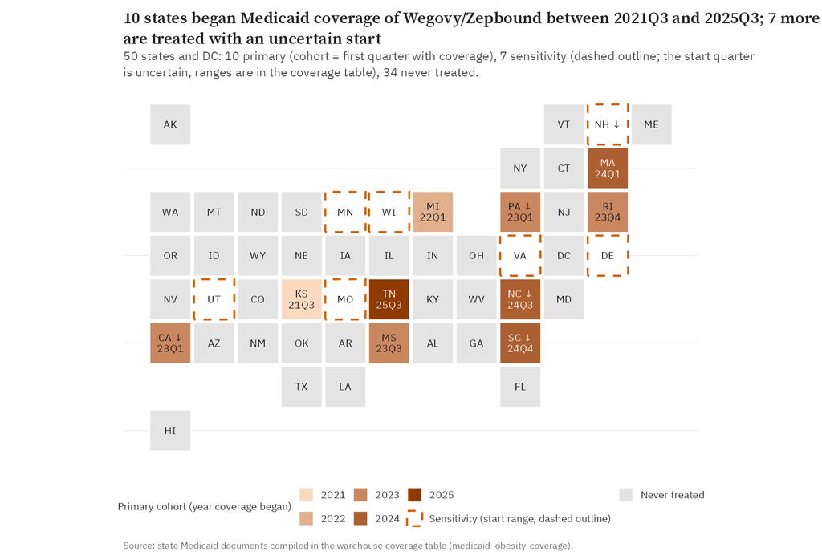

Primary tiles show the cohort quarter (23Q1 = 2023 Q1); ↓ = coverage later ended or lapsed. Data through SDUD 2026 Q1 (preliminary).

The map shows the 10 states in the primary analysis; 7 more with uncertain start quarters appear only in a sensitivity analysis. Prior authorization is documented in 9 of 10 of the covering states (California’s is not found in sourced documents), and BMI thresholds, comorbidity rules and step therapy are in the criteria table below.

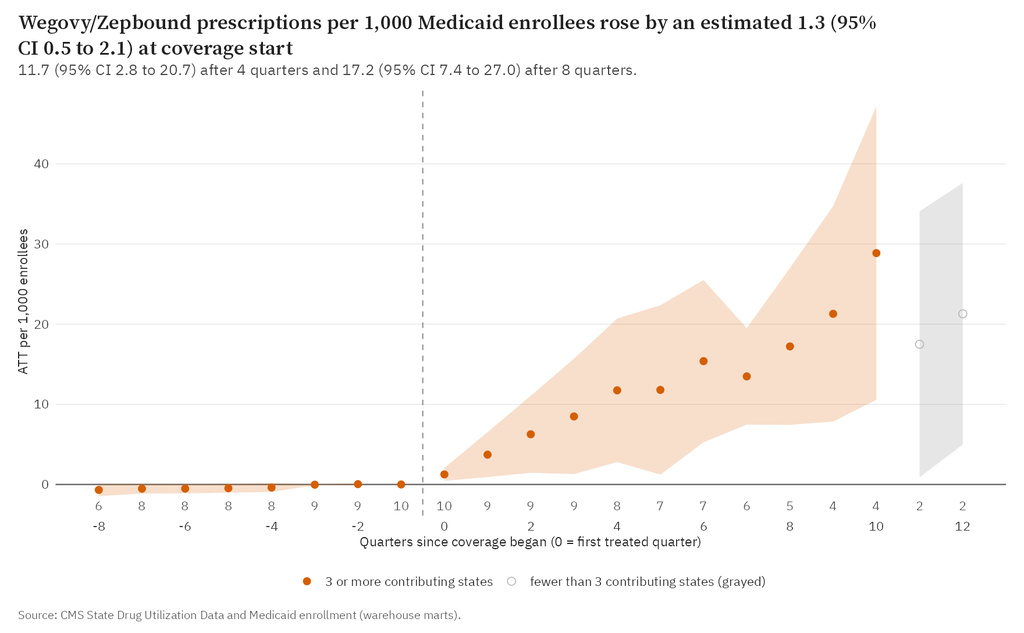

Callaway-Sant’Anna dynamic ATT, 10 primary states vs never- and not-yet-treated states, 2018 Q1 to 2025 Q3; 20 imputations of suppressed cells combined with Rubin’s rules. Shaded band and points: pointwise 95% CI; numbers along the bottom: contributing treated states; event times with fewer than 3 contributing states are grayed. Gross of rebates; counts under 11 suppressed by CMS. Simultaneous confidence bands are not shown: with single-state cohorts the bootstrap critical value is unreliable (did warns of this) and very large (17.9 on average over the imputations, versus 1.96 pointwise). Leads before 2021 Q2 (before Wegovy existed) are omitted: the outcome is mechanically zero there and they are not evidence of parallel trends.

Utilization-management criteria in the 17 covering states

Compact view; 'Not found' means no sourced document states it; criteria differ by period

| State | Delivery system | Prior authorization | BMI rule | Comorbidity | Step therapy | Source |
| --- | --- | --- | --- | --- | --- | --- |
| Mississippi | FFS | Yes | ≥ 30 | Yes | Yes | [link](https://medicaid.ms.gov/wp-content/uploads/2024/07/Anti-obesity-Select-Agents-PA-Criteria-7_1_2024.V4.pdf) |
| North Carolina | FFS | Yes | ≥ 30 | Yes | Yes | [link](https://medicaid.ncdhhs.gov/media/15676/download?attachment=) |
| Pennsylvania | FFS | Yes | ≥ 30 (adults) | Yes | Yes | [link](https://www.pa.gov/content/dam/copapwp-pagov/en/dhs/documents/docs/publications/documents/forms-and-pubs-omap/mab2025112402.pdf) |
| Michigan | FFS | Yes | GLP-1 weight-loss agents: BMI classified as m… | Yes | Yes | [link](https://www.michigan.gov/mdhhs/-/media/Project/Websites/mdhhs/Assistance-Programs/Medicaid-BPHASA/MHP-Common-Formulary-PDL-PA-Criteria.pdf) |
| Rhode Island | FFS | Yes | Not found | Not found | Not found | [link](https://eohhs.ri.gov/sites/g/files/xkgbur226/files/2024-06/dur_jun_24.pdf) |
| Massachusetts | FFS | Yes | ≥ 30 | Yes | Yes | [link](https://resources.massgeneralbrighamhealthplan.org/pharmacy/PharmacyPolicies/Medicaid/AntiObesity_PA_MH_Rx_01.01.25.pdf) |
| South Carolina | MCO (managed care program) | Yes | ≥ 30 | Yes | Not found | [link](https://scdailygazette.com/2025/01/07/as-demand-for-weight-loss-drugs-rises-states-grapple-with-medicaid-coverage/) |
| California | FFS | Not found | Not found | Not found | Not found | [link](https://medi-calrx.dhcs.ca.gov/cms/medicalrx/static-assets/documents/provider/pharmacy-news/2024.10_B_Monthly_Bulletin.pdf) |
| New Hampshire | FFS | Yes | Not found | Not found | Yes | [link](https://nh.primetherapeutics.com/documents/51139/51630/Notification%2010.09.2025%20-%20GLP-1%20Coverage%20Change/218c7285-7968-9484-a244-859e0741eeba) |
| Utah | FFS | Yes | ≥ 30 (adults) | Yes | Not found | [link](https://medicaid-documents.dhhs.utah.gov/Documents/manuals/pdfs/Medicaid+Information+Bulletins/Traditional+Medicaid+Program/2025/July2025-MIB.pdf) |
| Minnesota | FFS | Yes | ≥ 30 with no risk factors (age 18+) | Yes | Yes | [link](https://mn.gov/dhs/partners-and-providers/policies-procedures/minnesota-health-care-programs/provider/types/rx/pa-criteria/anti-obesity-medications.jsp) |
| Wisconsin | FFS | Yes | ≥ 30 (age 18+) | Yes | Yes | [link](https://www.dhs.wisconsin.gov/forms/f00163-1125.pdf) |
| Virginia | FFS | Yes | 2022 form: ≥ 30 (≥ 27 with two or more risk f… | Yes | Yes | [link](https://www.virginiamedicaidpharmacyservices.com/provider/external/medicaid/vamps/doc/en-us/VAMPS_SAform_Weight_Loss_Management.pdf) |
| Kansas | FFS | Yes | ≥ 30 (adults) | Yes | Yes | [link](https://www.kdhe.ks.gov/DocumentCenter/View/34035/Anti-Obesity-Agents-PDF) |
| Delaware | FFS | Yes | Not found | Yes | Yes | [link](https://medicaidpublications.dhss.delaware.gov/docs/search?Command=Core_Download&EntryId=940) |
| Missouri | FFS | Yes | ≥ 30 (adults) | Yes | Yes | [link](https://dss.mo.gov/media/file/glucagon-peptide-1-glp-1-receptor-agonists-indicated-obesity-pdl-edit) |
| Tennessee | FFS | Yes | ≥ 30 (adults) | Yes | Yes | [link](https://contenthub-aem.optumrx.com/content/dam/contenthub/onboarding/assets/Tenncare/Provider-Notice-Obesity-Management-Agents-08-01-25.pdf) |

Sources: state Medicaid agency documents; South Carolina's criteria are as reported by a news outlet quoting the state agency.

**Full criteria text for all 17 states**

| State | Delivery system | Prior authorization | BMI threshold | Comorbidity requirement | Step therapy | Criteria version (document) |
| --- | --- | --- | --- | --- | --- | --- |
| Mississippi | FFS | Y | >=30; BMI 27-29.9 with >=1 weight-related comorbidity | BMI 27-29 requires >=1 weight-related comorbidity (7/1/2024 criteria) | none stated in the criteria; only one anti-obesity agent covered at a time | MS Division of Medicaid Select Covered Obesity Medications PA Criteria V4 (7/1/2024); later versions (V7 to V11) add Zepbound and Foundayo |
| North Carolina | FFS | Y | >=30; BMI >=27 with >=1 weight-related comorbidity | >=27 with >=1 weight-related comorbidity (HTN, T2DM, OSA, CVD, dyslipidemia) | Y for non-preferred agents: trial of a preferred agent (or documented contraindication) | NC Medicaid Outpatient Pharmacy Prior Approval Criteria, GLP-1s for Weight Management (effective 2024-08-01) |
| Pennsylvania | FFS | Y | >=30 (adults) | BMI 27 to <30 with prescriber-determined candidacy criteria (2024 guidelines) | Y for non-preferred obesity agents: history of therapeutic failure of, contraindication or intolerance to the preferred Obesity Treatment Agents | PA Medical Assistance Bulletin MAB 2025-11-24 (criteria effective 2026-01-01, replacing 2024); earlier MAB 2022-12-09 |
| Michigan | FFS | Y | GLP-1 weight-loss agents: BMI classified as morbidly obese (e.g. >=40) in the 10/01/2026 criteria; earlier criteria not found in sourced documents | not required in the 10/01/2026 GLP-1 criteria (BMI >=40 route); earlier criteria not found in sourced documents | Y (10/01/2026 criteria): GLP-1s are non-preferred; trial and failure (or allergy, contraindication, side effects) of all five preferred non-GLP-1 types, failure of other weight-loss interventions, and… | MDHHS MHP Common Formulary Prior Authorization Criteria, anti-obesity section (effective 10/01/2026); MSA 21-49 (2021-12-01) for PA and start |
| Rhode Island | FFS | Y for some products (EOHHS memo: 'some medications may require prior authorization') | not found in sourced documents | not found in sourced documents | not found in sourced documents | RI EOHHS memo GLP-1 State Budget Guidance (2026-08-05); DUR Board minutes 2024-06-04 |
| Massachusetts | FFS | Y | >=30; or >=27 with a listed weight-related comorbidity | BMI >=27 plus one of: coronary heart disease or other atherosclerotic disease, dyslipidemia, hypertension, NASH, obstructive sleep apnea, PCOS, prediabetes, systemic osteoarthritis, type 2 diabetes | Y: inadequate response to, adverse reaction to, or contraindication to phentermine (and related agents) per the criteria; preferred-drug trial rules for non-preferred agents | MassHealth Anti-Obesity Agents PA criteria, effective 2025-01-01 (published by Mass General Brigham Health Plan for MassHealth) |
| South Carolina | MCO (managed care program); FFS not stated | Y | >=30; BMI 30-34 needs >=1 very high-risk factor or >=2 other risk factors; BMI 35-39 needs >=1 risk factor; BMI >=40 needs none | very high-risk: type 2 diabetes, coronary heart disease, sleep apnea; other risk factors: hypertension, cigarette smoking, family history of premature heart disease, osteoarthritis (as reported) | not found in sourced documents | SC Daily Gazette reports 2025-01-07 and 2025-11-17 quoting SCDHHS; no SCDHHS criteria document was retrieved |
| California | FFS | not found in sourced documents for the covered period (Zepbound was added to the Contract Drugs List with diagnosis, quantity and labeler restrictions, 2024-10-01); from 2026-01-01 weight-loss use is … | not found in sourced documents (the 2026 FAQ says no BMI range qualifies for weight-loss coverage after 2026-01-01) | not found in sourced documents | not found in sourced documents | Medi-Cal Rx Monthly Bulletin 2024-10 and State Budget Policy Updates FAQ (2026) |
| New Hampshire | FFS | Y (the PDL notes additional prior approval for the weight management class) | not found in sourced documents | not found in sourced documents | Y: trial and failure of 2 preferred products (orlistat, phentermine/topiramate) required before non-preferred products (Saxenda, Wegovy, Zepbound) | NH DHHS Fee-for-Service Medicaid PDL effective 2025-10-01 |
| Utah | FFS | Y | >=30 (adults) | BMI 27-29.9 with >=1 weight-related comorbidity; children BMI >=95th percentile | not found in sourced documents | Utah Medicaid Information Bulletins (January and July 2025) |
| Minnesota | FFS | Y | >=30 with no risk factors (age 18+) | BMI >=27 with >=1 weight-related comorbid condition (e.g. hypertension, type 2 diabetes, dyslipidemia) | none stated; documentation of a reduced-calorie diet or dietitian care and increased physical activity is required | MN DHS Anti-Obesity Medications PA criteria (August 2026 page) |
| Wisconsin | FFS | Y | >=30 (age 18+) | BMI 27 to <30 with >=2 risk factors (treated dyslipidemia, hypertension, sleep apnea, type 2 diabetes, or cardiovascular disease) | none stated; the member must have participated in a weight loss treatment plan in the past six months and continue it | ForwardHealth PA Drug Attachment for Anti-Obesity Drugs, F-00163 (11/2025); ForwardHealth Update 2025-16 |
| Virginia | FFS | Y (service authorization) | 2022 form: >=30 (>=27 with two or more risk factors); form effective 2026-07-01: GLP-1 weight-loss agents BMI >40, or >37 with dyslipidemia, hypertension or type 2 diabetes | 2022 form: >=27 with two or more of coronary heart disease, dyslipidemia, hypertension, sleep apnea, type 2 diabetes; 2026 form: >37 with one or more of dyslipidemia, hypertension, type 2 diabetes | Y (form effective 2026-07-01): tried and failed one non-GLP-1 weight-loss medication (or intolerant to all), and tried and failed the PDL-selected product; 2022 form: previous failure of a weight loss… | DMAS Service Authorization forms: Anti-Obesity Drugs (effective 2022-01-20) and Weight-Loss Management (effective 2026-07-01) |
| Kansas | FFS | Y | >=30 (adults); 'high-cost' agents (Table 4, includes Saxenda and Wegovy): severe obesity BMI >=40, or for Wegovy BMI >=27 with established cardiovascular disease | BMI >=27 with >=1 weight-related comorbidity (Table 2) | Y: the preferred PDL drug is required unless the patient meets non-preferred PDL criteria; 'high-cost' agents need >=3% weight loss after >=3 months of lifestyle modification | KDHE/KMAP Anti-Obesity Medications PA criteria (revised 2024-01-17) |
| Delaware | FFS | Y (the 2026 PDL: all obesity treatment agents require prior authorization) | not found in sourced documents | coverage is for obesity drugs 'to address weight loss with co-morbid conditions with prior authorization' (State Plan DE 19-0009) | Y: two preferred products are required before a non-preferred product (2026 PDL) | Delaware Medicaid PDL (live 10/05/2026); State Plan Amendment DE 19-0009 (effective 2019-10-01) |
| Missouri | FFS | Y (may be transparent: a billable ICD-10 obesity code on the claim can approve without PA) | >=30 (adults) | BMI >=27 with one of: hypertension, dyslipidemia, obstructive sleep apnea, prediabetes, previous myocardial infarction, previous stroke, symptomatic peripheral arterial disease; MASH with F2-F3 fibros… | Y: preferred agents (Zepbound, Foundayo) first; Wegovy is non-preferred and needs medical necessity for not using a preferred agent | MO HealthNet SmartPA Criteria, GLP-1 Receptor Agonists Indicated for Obesity PDL Edit (revised 2026-04-23) |
| Tennessee | FFS | Y (interim PA criteria from 2025-08-01; Wegovy and Zepbound preferred with PA and quantity limits) | >=30 (adults) | BMI >=27 with a weight-related comorbidity (e.g. hypertension, dyslipidemia, diabetes, coronary heart disease, MASH/NASH, obstructive sleep apnea) | none for the preferred agents (Wegovy, Zepbound); Y for non-preferred agents (Saxenda, liraglutide): trial and failure, contraindication or intolerance of two preferred agents | TennCare Provider Notice, Obesity Management Agents (2025-08-01) and Provider Notice 2025-12-01 |

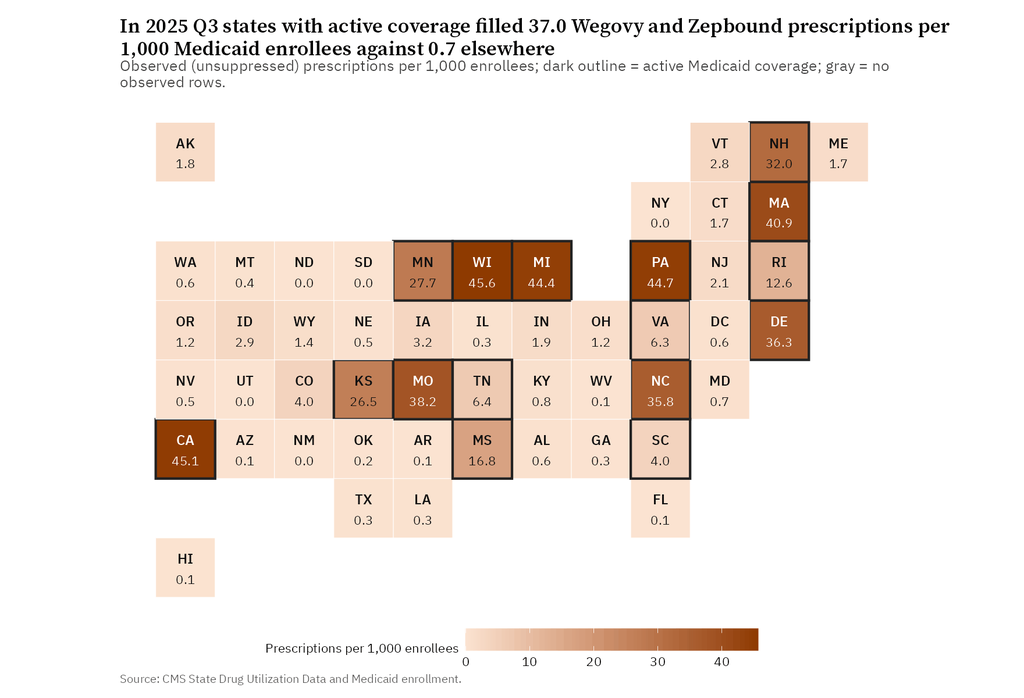

Observed counts only: cells under 11 are suppressed, so rates are lower bounds. 2025 Q3 is the last full quarter before the preliminary 2026 Q1 data.

The overall effect is 12.2 per 1,000 enrollees per quarter (95% CI 8.4 to 16.0). The estimate holds in all 15 estimable alternative analyses (fee-for-service only, specification 12, is not estimable). A different estimator (Sun and Abraham) gives 9.3 (95% CI 8.2 to 10.4), a wild cluster bootstrap by state gives an interval of 4.5 to 14.2, and the sensitivity analyses range from 10.1 to 14.7. A managed-care-only outcome (sensitivity 14, per managed-care enrollee, so a different denominator) gives 12.5 (95% CI 6.0 to 19.0). A placebo with coverage moved four quarters earlier gives 0.4 (95% CI -0.1 to 0.8). The result tolerates a violation of parallel trends up to 1.4 times the largest pre-period violation (HonestDiD). Saxenda (0.2, 95% CI -0.3 to 0.7) and diabetes GLP-1 products (-0.8, 95% CI -4.2 to 2.7) show no effect.

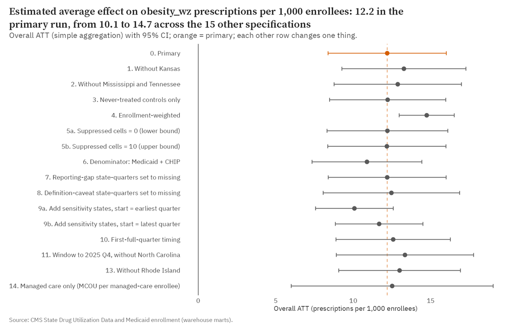

Gross of rebates; counts under 11 suppressed by CMS. Specification 12 (fee-for-service only) is not shown: not estimable reliably (FFS denominators too small; coverage operates mainly through MCOs in SC and RI). It is listed in the specification table.

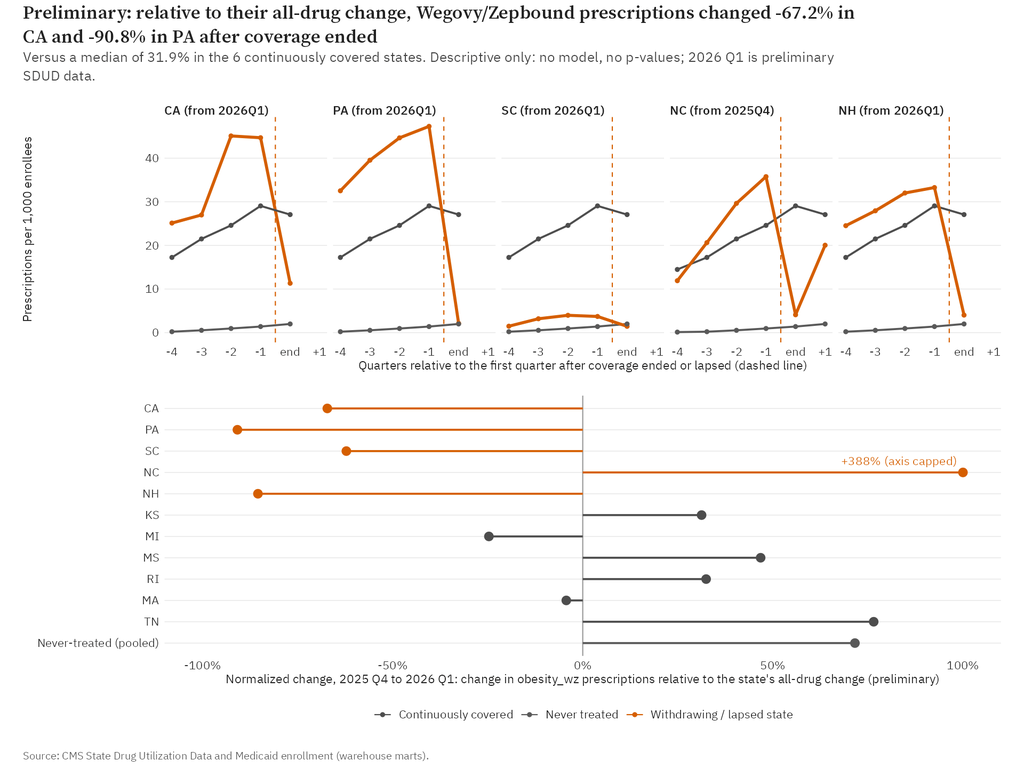

Normalized change = (1 + obesity_wz change) / (1 + all-drug SDUD change) - 1 for 2025 Q4 to 2026 Q1; raw changes are in the table (obesity_wz: CA -75.7%, PA -95.5%, continuously covered median -1.6%; all drugs: CA -26.0%, PA -51.0%, median -17.9%). Gross of rebates; counts under 11 suppressed by CMS. PRELIMINARY: 2026 Q1 is preliminary SDUD data; only one post-withdrawal quarter exists for most states (North Carolina lapsed 2025-10-01 to 2025-12-11 and resumed). New Hampshire is a sensitivity state.

# D. Prescribers

Primary care writes most Part D incretin claims, which reflect diabetes and other covered uses.

Part D reflects diabetes and other covered uses, not obesity-brand adoption.

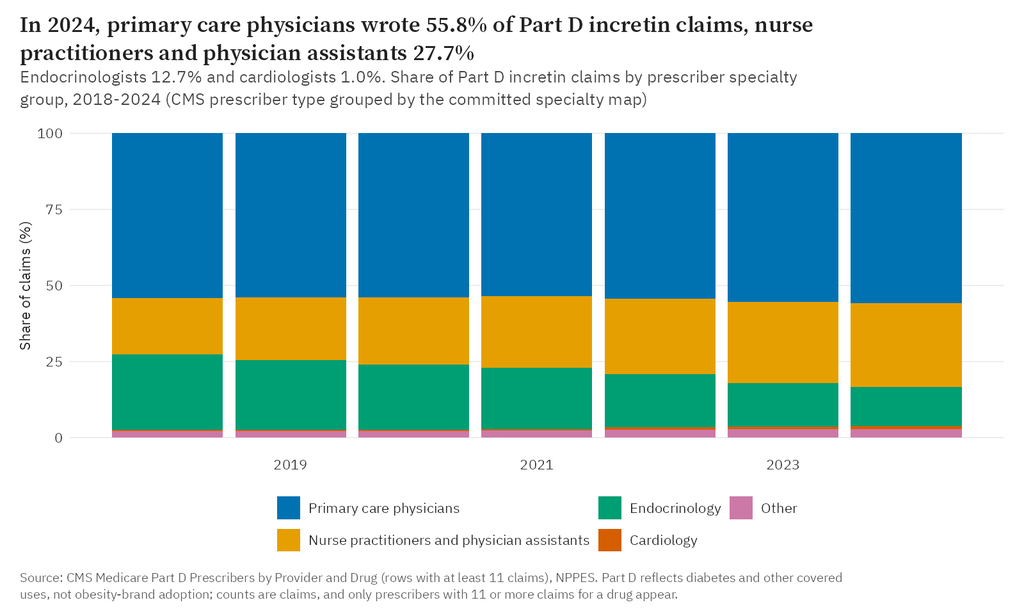

Source: CMS Medicare Part D Prescribers by Provider and Drug (rows with at least 11 claims); specialty from CMS prescriber type.

Part D incretin claims grew from 2.6 million in 2018 to 19.6 million in 2024, and prescribers from 56,306 to 199,822. In 2024, primary care physicians wrote 55.8% of claims, nurse practitioners and physician assistants 27.7%, endocrinology 12.7% and cardiology 1.0%; the NPPES taxonomy agrees with the specialty grouping for 95.4% of prescribers. The top 10% of prescribers wrote 43.2% of claims in 2018 and 41.4% in 2024 (Gini 0.551 in 2024).

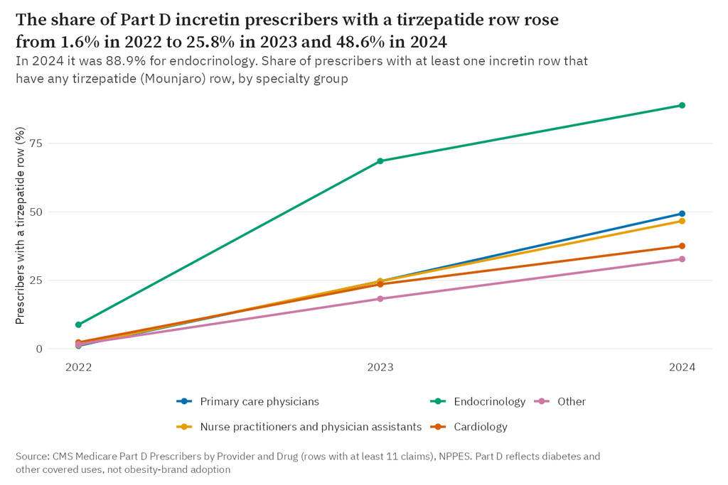

Counts are claims, and only prescribers with 11 or more claims for a drug appear.

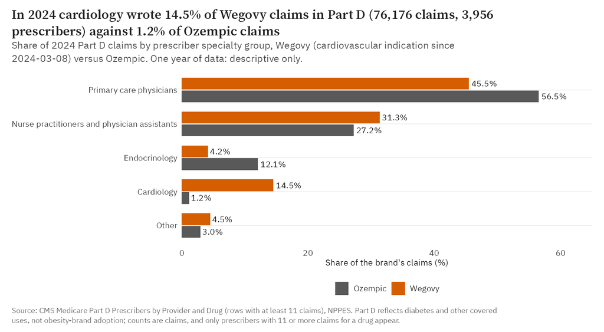

Source: CMS Medicare Part D Prescribers, 2024; Wegovy’s Part D claims reflect its cardiovascular indication, not obesity use.

The share of prescribers with tirzepatide claims rose from 1.6% in 2022 to 25.8% in 2023 and 48.6% in 2024. Wegovy had 76,176 Part D claims from 3,956 prescribers in 2024; cardiology wrote 14.5% of them against 1.2% of Ozempic claims, consistent with the cardiovascular indication added in March 2024.

**Segments (exploratory).** The pre-specified rule gave a two-segment split of new versus continuing prescribers. A supplementary five-segment solution, shown with its stability beside each segment, is exploratory:

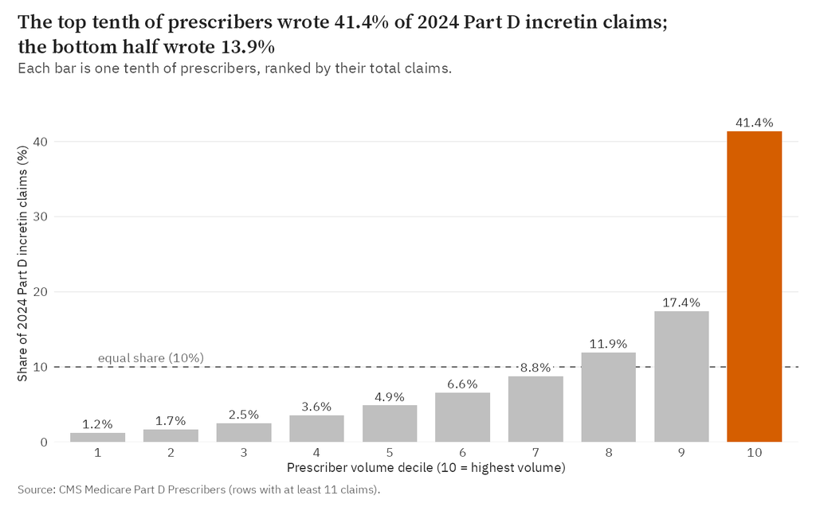

Part D reflects diabetes and other covered uses, not obesity-brand adoption. Aggregates only.

[output not shown]

Decile 10 = highest-volume tenth of the 199,822 prescribers.

Volume is concentrated: the top decile of prescribers wrote 41.4% of 2024 claims and the bottom five deciles together 13.9%.

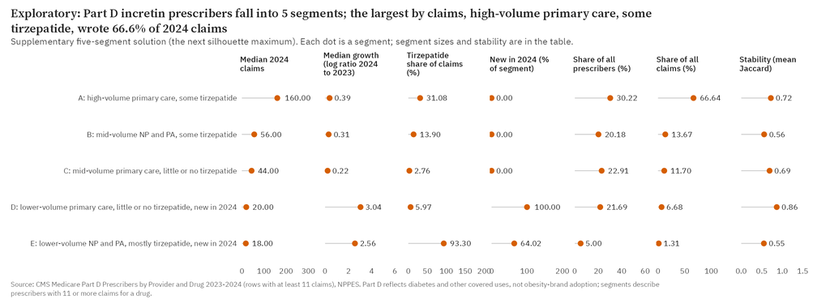

Stability: mean Jaccard over 50 bootstrap resamples.

**Open Payments (association only; technical report, not for headlines).** In 2023, 36.6% of 2024 prescribers had in-scope payments. The negative binomial model uses log(1 + dollars) as the predictor, so a “per $1,000” statement would be wrong; the clear contrasts are incidence rate ratios for 2024 claims: any 2023 payment versus none at the median payee amount, 1.30 (95% CI 1.29 to 1.31), and 1.05 (95% CI 1.04 to 1.05) per doubling of the amount among payees. Payments go to prescribers who already write more; these are associations, not effects of payments, and no individual or company is identified.

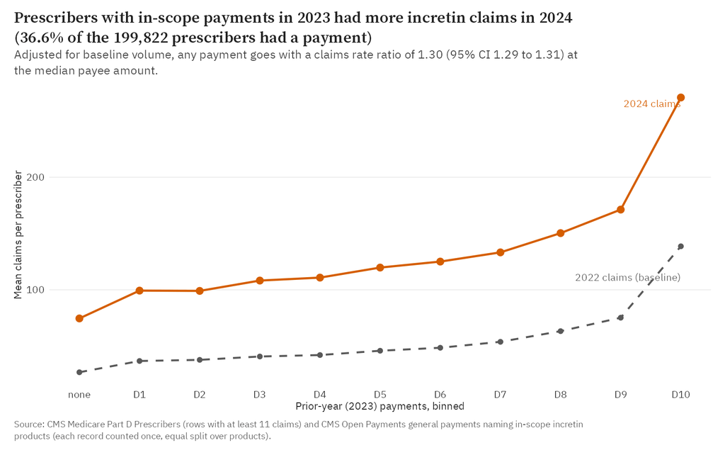

Mean 2024 Part D incretin claims (solid) and mean 2022 claims (dashed) by 2023 payment bin: no payment, then deciles of positive payment amounts (D1 lowest, D10 highest). Binned and aggregate; an association, not an effect of payments. Part D reflects diabetes and other covered uses, not obesity-brand adoption. Association only: payments are not randomly assigned.

# E. Budget impact

About $161 million over five years for 1 million enrollees, with the rebate the biggest unknown.

The model scales Module C’s extra prescriptions per 1,000 enrollees to a program of 1 million enrollees and prices them. Module C measures filled prescriptions in states that already applied their own prior authorization rules, so the central case uses the effect as observed (multiplier 1.0, “PA as observed in the 10 covering states”); tight and loose prior authorization are assumption scenarios. The central rebate is 51.2% (midpoint of 23.1% and 79.3%), where 23.1% is the statutory minimum (42 U.S.C. 1396r-8) and 79.3% is the rebate implied by the announced $245 price; actual net prices are confidential. No medical cost offsets are included because no published source supporting a five-year offset was retrieved.

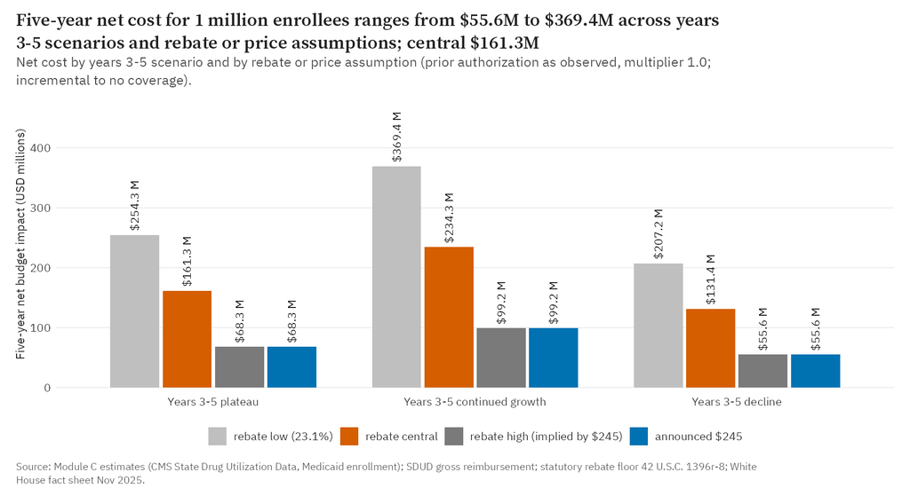

SDUD amounts are gross of rebates; rebates, prior authorization and years 3-5 are assumptions.

In the central case the five-year net cost is $161.3 million ($2.69 per enrollee per month; gross $330.7 million, $5.51 per month), with $11.4, $30.3 and $39.9 million in years 1 to 3. About 15,873 members a year are users at the plateau, out of 300,948 eligible Medicaid adults in the plan. Two per-member costs answer different questions: **net cost per user per year** (4.3 fills a year, MEPS, sourced) is $2,511, and **net cost per member-year of continuous treatment** (12 fills a year, assumption) is $6,943. The gross reimbursement per prescription is $1,186 (range 1,164 to 1,252), measured in SDUD and consistent with NADAC within 3%.

The probabilistic range (10,000 draws) has a median of $145.4 million (90% interval 58.1 to 319.9 million), or $50.3 to 347.3 million if the effects at different event times move together. Prior authorization scenarios (five-year net, central rebate): tight at multiplier 0.5, $80.7 million; tight at 0.75, $121.0 million; loose at 1.25, $201.6 million.

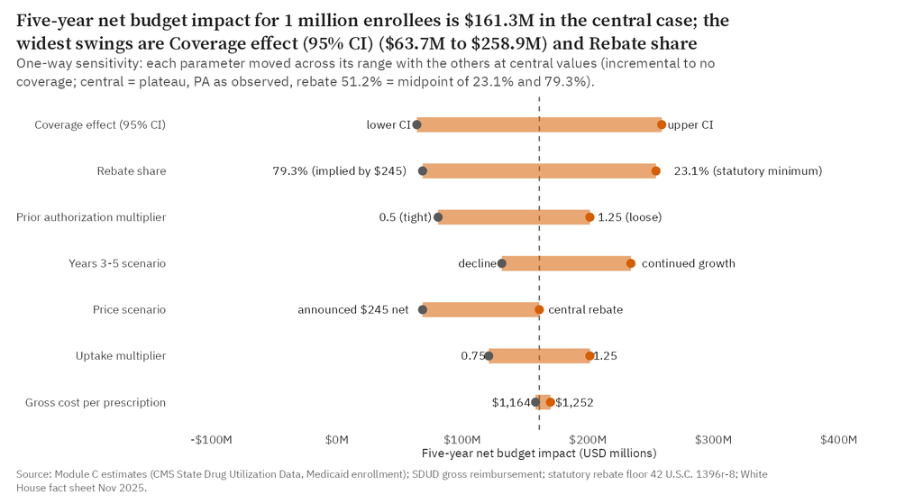

SDUD amounts are gross of rebates; rebates, prior authorization and years 3-5 are assumptions.

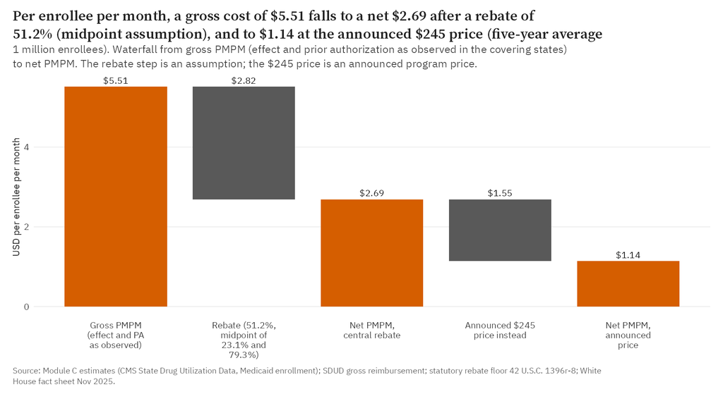

SDUD amounts are gross of rebates; rebates, prior authorization and years 3-5 are assumptions.

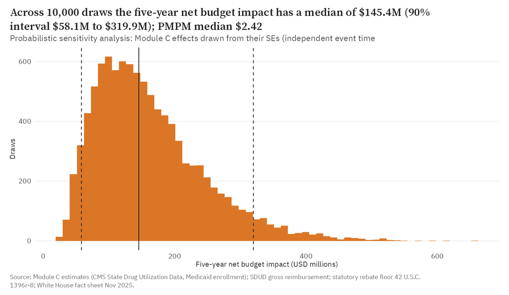

## Value context: trial efficacy next to net cost (context only)

Trial weight loss and Medicaid net cost per user per year

Context only: different populations, durations and fills; no cost-effectiveness claim

| Trial | Arm | Dose | Weeks | Weight change, % (95% CI) | Medicaid gross reimbursement per prescription, covering states, 2025, USD | Net cost per user per year, USD (4.3 fills, midpoint rebate; blended Wegovy and Zepbound) | Net cost per member-year of continuous treatment, USD (12 fills, assumption) |
| --- | --- | --- | --- | --- | --- | --- | --- |
| STEP 1 | semaglutide | 2.4 mg once weekly (subcutaneous) | 68 | -14.9 (arm CI not in abstract) | 1,303 | 2,511 | 6,943 |
| SURMOUNT-1 | tirzepatide 5 mg | 5 mg once weekly (subcutaneous) | 72 | -15.0 (-15.9 to -14.2) | 1,048 | 2,511 | 6,943 |
| SURMOUNT-1 | tirzepatide 10 mg | 10 mg once weekly | 72 | -19.5 (-20.4 to -18.5) | 1,048 | 2,511 | 6,943 |
| SURMOUNT-1 | tirzepatide 15 mg | 15 mg once weekly | 72 | -20.9 (-21.8 to -19.9) | 1,048 | 2,511 | 6,943 |
| SURMOUNT-5 | tirzepatide | maximum tolerated dose (10 mg or 15 mg) once weekly | 72 | -20.2 (-21.4 to -19.1) | 1,048 | 2,511 | 6,943 |
| SURMOUNT-5 | semaglutide | maximum tolerated dose (1.7 mg or 2.4 mg) once weekly | 72 | -13.7 (-14.9 to -12.6) | 1,303 | 2,511 | 6,943 |
| ATTAIN-1 | orforglipron 6 mg | 6 mg once daily (oral) | 72 | -7.5 (-8.2 to -6.8) | not a Medicaid-covered obesity product in the SDUD window | 2,511 | 6,943 |
| ATTAIN-1 | orforglipron 12 mg | 12 mg once daily | 72 | -8.4 (-9.1 to -7.7) | not a Medicaid-covered obesity product in the SDUD window | 2,511 | 6,943 |
| ATTAIN-1 | orforglipron 36 mg | 36 mg once daily | 72 | -11.2 (-12.0 to -10.4) | not a Medicaid-covered obesity product in the SDUD window | 2,511 | 6,943 |

Trials: published abstracts via PubMed (STEP 1, SURMOUNT-1, SURMOUNT-5, ATTAIN-1; citations and DOIs in data/reference/trial_inputs.csv). Costs: Module E, net of an assumed rebate of 51.2%; one blended Wegovy and Zepbound net cost is shown for every row.

Published primary results range from -7.5% (orforglipron 6 mg, 72 weeks) to -20.9% (tirzepatide 15 mg, 72 weeks) mean body-weight change; semaglutide 2.4 mg gave -14.9% at 68 weeks (STEP 1) and head-to-head tirzepatide gave -20.2% against -13.7% for semaglutide (SURMOUNT-5). Against these, the Module E central net cost is $2,511 per user per year (4.3 fills, MEPS) and $6,943 per member-year of continuous treatment (12 fills, assumption). The trials, populations, durations and Medicaid fills differ, so this table supports no cost-effectiveness, cost-per-kilogram or QALY statement.

The interactive model is a hosted decision tool at https://erickyegon.github.io/incretin-access-value/budget-model.html (also runnable locally with `shiny::runApp("app")`); a static PDF of the scenarios is in `analysis/outputs/budget_impact_scenarios.pdf`.

# F. Research pack

A design for primary research, with no fieldwork done.

Module F is a design pack, rendered as `research_pack/research_pack.pdf`: a one-page brief from a fictional access team, prescriber and payer screeners with quotas, a 60-minute discussion guide with probes tied to the findings above, fictional stimulus boards, a discrete choice experiment (five attributes, three levels, 24 tasks in two blocks of 12, an efficient design from `idefix` with a zero prior), sample size by the Johnson and Orme rule of thumb and by simulation, and an analysis framework. No respondents exist and no interviews have been fielded; the recommendation slides are marked illustrative and carry only secondary-data numbers.

# Exploration notebooks

One short notebook per module, built only from the existing outputs (no new analysis): A, data layer, B, eligible population, C, coverage study, D, prescribers and E, budget impact. The data dictionary (marts, units, suppression, NDC rather than HCPCS) is docs/data_dictionary.md.

# Limitations

- **Gross, not net.** SDUD amounts are gross of rebates; the rebate range is an assumption between a statutory floor and a price-implied ceiling.
- **Ten treated states.** The effect comes from 10 states and may not carry over to other states or later years; later event times fall in later calendar quarters, so part of the growth is market growth.
- **Eligibility is a lower bound.** NHANES does not measure every qualifying condition; modeled use steps rely on KFF poll estimates.
- **Part D is not obesity use.** Part D claims reflect diabetes and other covered uses; prescriber findings are not about obesity-brand adoption.
- **Suppressed cells.** SDUD hides counts under 11; the analysis imputes them and combines 20 imputations.
- **No offsets, no outcomes.** The budget model has no medical cost offsets and does not estimate health outcomes.
- **Associations, scenarios.** Payments results are associations; the budget model and forecast are scenarios, not forecasts.
- **Preliminary data.** SDUD 2026 Q1 is preliminary; the withdrawal figures are descriptive.

# Reproducibility

The code, the dbt project and the scripts are in the repository; raw and interim data are not committed and are re-downloaded by the scripts in `scripts/fetch`. In order: load (`scripts/load`), build (`dbt build` in `dbt/`), analyze (`analysis/run_all.R`, then `scripts/build/build_counts.py` and `analysis/scripts/50_key_numbers.R`), render (`quarto render report`, `deck`, `research_pack`). Every source is listed with its URL, access date and checksum in `docs/sources_index.csv`; U.S. government documents and open-license manuals are kept in `docs/sources/`, and copies of copyrighted third-party pages stay local only, and the R packages are pinned in `analysis/renv.lock`.

# AI-use statement

I used AI tools to help write code and documentation. The study design, methods and conclusions are my own, and I verified all results.